Zijing Cheng(Mavis, zc233)

Notes: If you can not find the menu button you want, you can make your webpage narrower, then you can find the menu button in the upper right corner.

# Naive Bayes

Zijing Cheng zc233

2022-10-11

```r
library(naivebayes)
library(tidyverse)
```

```r
library(ggplot2)
            library(psych)
df = read.csv("cleaned_data_r.csv")
            df=df%>%mutate(retweeted = ifelse(retweet_count>0, T, F))
            df = df[,-c(1,2)]
```

## Let’s take a look of labeled record data in R part.

```r
head(df)
```

```
##   truncated retweet_count favorite_count favorited retweeted lang
            ## 1     False          1060              0     False      TRUE   en
            ## 2     False             0              0     False     FALSE   en
            ## 3     False            53              0     False      TRUE   en
            ## 4     False           179              0     False      TRUE   en
            ## 5     False           161              0     False      TRUE   en
            ## 6     False           106              0     False      TRUE   en
            ##   followers_count friends_count favourites_count has_extended_profile
            ## 1               5             7                8                 TRUE
            ## 2               1             2                2                 TRUE
            ## 3               1             7                1                 TRUE
            ## 4               5             5                1                 TRUE
            ## 5               7             9                2                 TRUE
            ## 6               3             1                3                FALSE
```

### Data preparation includes extracting dependent variable, retweeted, whether the tweet is retweeted or not and independent variables, as it shows below. And it also includes the process of spliting training and testing sets. And I split the labeled text data into train and test with 70% trainning ratio.

```r
set.seed(1)
            ind <- sample(2, nrow(df), replace = T, prob = c(0.7, 0.3))
            train <- df[ind == 1,]
            test <- df[ind == 2,]
```

##Train the Naive Bayes model ### In this method, the assumption of Naive Bayes assumption is that each feature makes an independent and equal contribution to the outcome. So the main idea is that we create a classifier model then we find the probability of given set of inputs for all possible values of the class variable. and pick up the output with maximum probability. The output means the class with higher probability. And the outputs will show whether these inputs are a good way to make prediction, or, classification.

```r
model <- naive_bayes(retweeted ~ ., data = train, usekernel = T,laplace = 1)
```

```r
p <- predict(model, train[,-5], type = 'prob')
            head(cbind(p, train))
```

```
##       FALSE        TRUE truncated retweet_count favorite_count favorited
            ## 1 0.8826936 0.117306439     False          1060              0     False
            ## 2 0.9969731 0.003026911     False             0              0     False
            ## 3 0.7014710 0.298529046     False            53              0     False
            ## 5 0.9330822 0.066917798     False           161              0     False
            ## 8 0.8449123 0.155087722     False           504              0     False
            ## 9 0.7253097 0.274690256     False           311              0     False
            ##   retweeted lang followers_count friends_count favourites_count
            ## 1      TRUE   en               5             7                8
            ## 2     FALSE   en               1             2                2
            ## 3      TRUE   en               1             7                1
            ## 5      TRUE   en               7             9                2
            ## 8      TRUE   en               1             1                1
            ## 9      TRUE   en               2             3                8
            ##   has_extended_profile
            ## 1                 TRUE
            ## 2                 TRUE
            ## 3                 TRUE
            ## 5                 TRUE
            ## 8                FALSE
            ## 9                FALSE
```

```r
p1 <- predict(model, train[,-5])
            tab1 <- table(p1, train$retweeted)
            print(tab1)
```

```
##
            ## p1      FALSE TRUE
            ##   FALSE    28   40
            ##   TRUE      0    0
```

```r
1 - sum(diag(tab1)) / sum(tab1)
```

```
## [1] 0.5882353
```

```r
p2 <- predict(model, test[,-5])
            (tab2 <- table(p2, test$retweeted))
```

```
##
            ## p2      FALSE TRUE
            ##   FALSE    11   21
            ##   TRUE      0    0
```

```r
1 - sum(diag(tab2)) / sum(tab2)
```

```
## [1] 0.65625
```

### From the above tables, we can conclude that the misclassification ratio is around 59%, which is very bad, as the expecation of randomly choose is 0.5. So it is not a good way to classify which tweet is retweeted. And from the prediction of test data, we can find that the misclassifictaion ratio is worse.

```r
library(pROC)
testy = ifelse(test[,5]==T,1,0)
            p2 = ifelse(p2==T,1,0)
            modelroc <- roc(testy,p2)
```

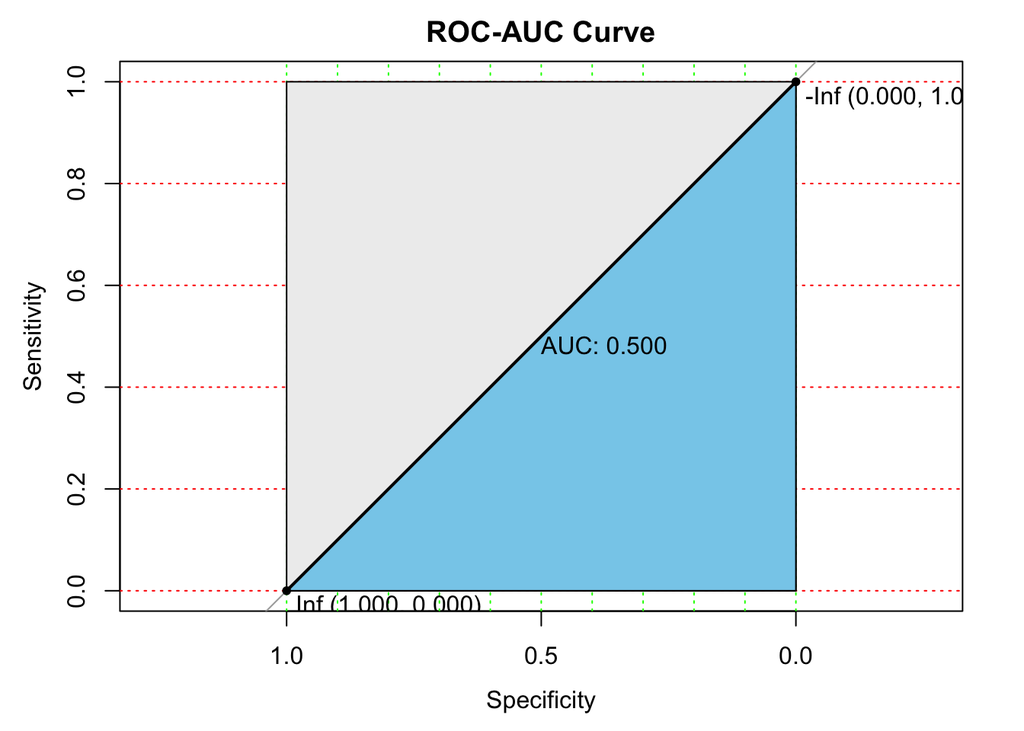

```r
plot(modelroc, print.auc=TRUE, auc.polygon=TRUE, grid=c(0.1, 0.2),
                 grid.col=c("green", "red"), max.auc.polygon=TRUE,
                 auc.polygon.col="skyblue", print.thres=TRUE,main = "ROC-AUC Curve")
```

[figure not shown]

```r
TClass <- factor(c(0, 0, 1, 1))
            PClass <- factor(c(0, 1, 0, 1))
            Y      <- c(0, 11, 0, 21)
            df <- data.frame(TClass, PClass, Y)
            library(ggplot2)
            ggplot(data =  df, mapping = aes(x = TClass, y = PClass)) +
              geom_tile(aes(fill = Y), colour = "white") +
              geom_text(aes(label = sprintf("%1.0f", Y)), vjust = 1) +
              scale_fill_gradient(low = "skyblue", high = "red") +
              theme_bw() + theme(legend.position = "none")+ggtitle("Confusion Matrix")
```

### Email

zc233@georgetown.edu